# Risk Factor Analysis

## Outcome Variable

**Outcome Variable:** ever_wasted

## Predictor Variables

**Intervention Variable:** mwtkg

**Adjustment Set:**

- arm
- W_mage
- meducyrs
- feducyrs
- W_nchldlt5
- brthmon
- W_parity
- delta_W_mage
- delta_meducyrs
- delta_feducyrs
- delta_W_nchldlt5
- delta_brthmon
- delta_W_parity

## Stratifying Variables

The analysis was stratified on these variable(s):

- agecat
- studyid
- country

## Data Summary

| agecat | studyid | country | mwtkg | ever_wasted | n_cell | n |
| --- | --- | --- | --- | --- | --- | --- |
| 0-24 months | iLiNS-Zinc | BURKINA FASO | >=58 kg | 0 | 764 | 3217 |
| 0-24 months | iLiNS-Zinc | BURKINA FASO | >=58 kg | 1 | 173 | 3217 |
| 0-24 months | iLiNS-Zinc | BURKINA FASO | <52 kg | 0 | 865 | 3217 |
| 0-24 months | iLiNS-Zinc | BURKINA FASO | <52 kg | 1 | 336 | 3217 |
| 0-24 months | iLiNS-Zinc | BURKINA FASO | [52-58) kg | 0 | 855 | 3217 |
| 0-24 months | iLiNS-Zinc | BURKINA FASO | [52-58) kg | 1 | 224 | 3217 |
| 0-24 months | JiVitA-3 | BANGLADESH | >=58 kg | 0 | 506 | 26925 |
| 0-24 months | JiVitA-3 | BANGLADESH | >=58 kg | 1 | 155 | 26925 |
| 0-24 months | JiVitA-3 | BANGLADESH | <52 kg | 0 | 18166 | 26925 |
| 0-24 months | JiVitA-3 | BANGLADESH | <52 kg | 1 | 6340 | 26925 |
| 0-24 months | JiVitA-3 | BANGLADESH | [52-58) kg | 0 | 1306 | 26925 |
| 0-24 months | JiVitA-3 | BANGLADESH | [52-58) kg | 1 | 452 | 26925 |
| 0-24 months | LCNI-5 | MALAWI | >=58 kg | 0 | 109 | 838 |
| 0-24 months | LCNI-5 | MALAWI | >=58 kg | 1 | 5 | 838 |
| 0-24 months | LCNI-5 | MALAWI | <52 kg | 0 | 457 | 838 |
| 0-24 months | LCNI-5 | MALAWI | <52 kg | 1 | 47 | 838 |
| 0-24 months | LCNI-5 | MALAWI | [52-58) kg | 0 | 206 | 838 |
| 0-24 months | LCNI-5 | MALAWI | [52-58) kg | 1 | 14 | 838 |
| 0-24 months | MAL-ED | BANGLADESH | >=58 kg | 0 | 39 | 254 |
| 0-24 months | MAL-ED | BANGLADESH | >=58 kg | 1 | 9 | 254 |
| 0-24 months | MAL-ED | BANGLADESH | <52 kg | 0 | 97 | 254 |
| 0-24 months | MAL-ED | BANGLADESH | <52 kg | 1 | 65 | 254 |
| 0-24 months | MAL-ED | BANGLADESH | [52-58) kg | 0 | 33 | 254 |
| 0-24 months | MAL-ED | BANGLADESH | [52-58) kg | 1 | 11 | 254 |
| 0-24 months | MAL-ED | BRAZIL | >=58 kg | 0 | 132 | 221 |
| 0-24 months | MAL-ED | BRAZIL | >=58 kg | 1 | 11 | 221 |
| 0-24 months | MAL-ED | BRAZIL | <52 kg | 0 | 40 | 221 |
| 0-24 months | MAL-ED | BRAZIL | <52 kg | 1 | 2 | 221 |
| 0-24 months | MAL-ED | BRAZIL | [52-58) kg | 0 | 30 | 221 |
| 0-24 months | MAL-ED | BRAZIL | [52-58) kg | 1 | 6 | 221 |

[output cut: 270 more lines]

The following strata were considered:

- agecat: 0-24 months, studyid: iLiNS-Zinc, country: BURKINA FASO
- agecat: 0-24 months, studyid: JiVitA-3, country: BANGLADESH
- agecat: 0-24 months, studyid: LCNI-5, country: MALAWI
- agecat: 0-24 months, studyid: MAL-ED, country: BANGLADESH
- agecat: 0-24 months, studyid: MAL-ED, country: BRAZIL
- agecat: 0-24 months, studyid: MAL-ED, country: INDIA
- agecat: 0-24 months, studyid: MAL-ED, country: NEPAL
- agecat: 0-24 months, studyid: MAL-ED, country: PERU
- agecat: 0-24 months, studyid: MAL-ED, country: SOUTH AFRICA
- agecat: 0-24 months, studyid: MAL-ED, country: TANZANIA, UNITED REPUBLIC OF
- agecat: 0-24 months, studyid: NIH-Birth, country: BANGLADESH
- agecat: 0-24 months, studyid: NIH-Crypto, country: BANGLADESH
- agecat: 0-24 months, studyid: PROBIT, country: BELARUS
- agecat: 0-24 months, studyid: PROVIDE, country: BANGLADESH
- agecat: 0-24 months, studyid: SAS-CompFeed, country: INDIA
- agecat: 0-24 months, studyid: TanzaniaChild2, country: TANZANIA, UNITED REPUBLIC OF
- agecat: 0-24 months, studyid: ZVITAMBO, country: ZIMBABWE
- agecat: 0-6 months, studyid: JiVitA-3, country: BANGLADESH
- agecat: 0-6 months, studyid: LCNI-5, country: MALAWI
- agecat: 0-6 months, studyid: MAL-ED, country: BANGLADESH
- agecat: 0-6 months, studyid: MAL-ED, country: BRAZIL
- agecat: 0-6 months, studyid: MAL-ED, country: INDIA
- agecat: 0-6 months, studyid: MAL-ED, country: NEPAL
- agecat: 0-6 months, studyid: MAL-ED, country: PERU
- agecat: 0-6 months, studyid: MAL-ED, country: SOUTH AFRICA
- agecat: 0-6 months, studyid: MAL-ED, country: TANZANIA, UNITED REPUBLIC OF
- agecat: 0-6 months, studyid: NIH-Birth, country: BANGLADESH
- agecat: 0-6 months, studyid: NIH-Crypto, country: BANGLADESH
- agecat: 0-6 months, studyid: PROBIT, country: BELARUS
- agecat: 0-6 months, studyid: PROVIDE, country: BANGLADESH
- agecat: 0-6 months, studyid: SAS-CompFeed, country: INDIA
- agecat: 0-6 months, studyid: TanzaniaChild2, country: TANZANIA, UNITED REPUBLIC OF
- agecat: 0-6 months, studyid: ZVITAMBO, country: ZIMBABWE
- agecat: 6-24 months, studyid: iLiNS-Zinc, country: BURKINA FASO
- agecat: 6-24 months, studyid: JiVitA-3, country: BANGLADESH
- agecat: 6-24 months, studyid: LCNI-5, country: MALAWI
- agecat: 6-24 months, studyid: MAL-ED, country: BANGLADESH
- agecat: 6-24 months, studyid: MAL-ED, country: BRAZIL
- agecat: 6-24 months, studyid: MAL-ED, country: INDIA
- agecat: 6-24 months, studyid: MAL-ED, country: NEPAL
- agecat: 6-24 months, studyid: MAL-ED, country: PERU
- agecat: 6-24 months, studyid: MAL-ED, country: SOUTH AFRICA
- agecat: 6-24 months, studyid: MAL-ED, country: TANZANIA, UNITED REPUBLIC OF
- agecat: 6-24 months, studyid: NIH-Birth, country: BANGLADESH
- agecat: 6-24 months, studyid: NIH-Crypto, country: BANGLADESH
- agecat: 6-24 months, studyid: PROBIT, country: BELARUS
- agecat: 6-24 months, studyid: PROVIDE, country: BANGLADESH
- agecat: 6-24 months, studyid: SAS-CompFeed, country: INDIA
- agecat: 6-24 months, studyid: TanzaniaChild2, country: TANZANIA, UNITED REPUBLIC OF
- agecat: 6-24 months, studyid: ZVITAMBO, country: ZIMBABWE

### Dropped Strata

Some strata were dropped due to rare outcomes:

- agecat: 0-24 months, studyid: MAL-ED, country: BRAZIL
- agecat: 0-6 months, studyid: LCNI-5, country: MALAWI
- agecat: 0-6 months, studyid: MAL-ED, country: BRAZIL
- agecat: 0-6 months, studyid: MAL-ED, country: PERU
- agecat: 0-6 months, studyid: MAL-ED, country: SOUTH AFRICA
- agecat: 0-6 months, studyid: MAL-ED, country: TANZANIA, UNITED REPUBLIC OF
- agecat: 6-24 months, studyid: MAL-ED, country: BANGLADESH
- agecat: 6-24 months, studyid: MAL-ED, country: BRAZIL
- agecat: 6-24 months, studyid: MAL-ED, country: INDIA
- agecat: 6-24 months, studyid: MAL-ED, country: PERU
- agecat: 6-24 months, studyid: MAL-ED, country: SOUTH AFRICA
- agecat: 6-24 months, studyid: MAL-ED, country: TANZANIA, UNITED REPUBLIC OF

## Methods Detail

We're interested in the causal parameters $E[Y_a]$ for all values of $a \in \mathcal{A}$. These parameters represent the mean outcome if, possibly contrary to fact, we intervened to set all units to have $A=a$. Under the randomization and positivity assumptions, these are identified by the statistical parameters $\psi_a=E_W[E_{Y|A,W}(Y|A=a,W)]$. In addition, we're interested in the mean of $Y$, $E[Y]$ under no intervention (the observed mean). We will estimate these parameters by using SuperLearner to fit the relevant likelihood factors -- $E_{Y|A,W}(Y|A=a,W)$ and $p(A=a|W)$, and then updating our likelihood fit using a joint TMLE.

For unadjusted analyses ($W=\{\}$), initial likelihoods were estimated using Lrnr_glm to estimate the simple $E(Y|A)$ and Lrnr_mean to estimate $p(A)$. For adjusted analyses, a small library containing Lrnr_glmnet, Lrnr_xgboost, and Lrnr_mean was used.

Having estimated these parameters, we will then use the delta method to estimate relative risks and attributable risks relative to a prespecified baseline level of $A$.

# Results Detail

## Results Plots

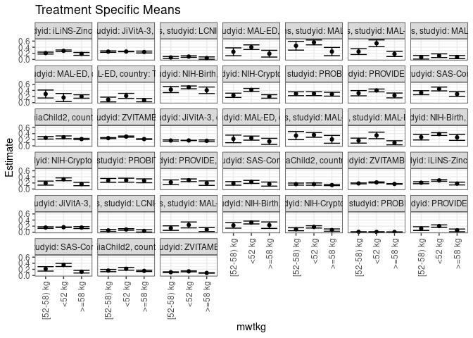

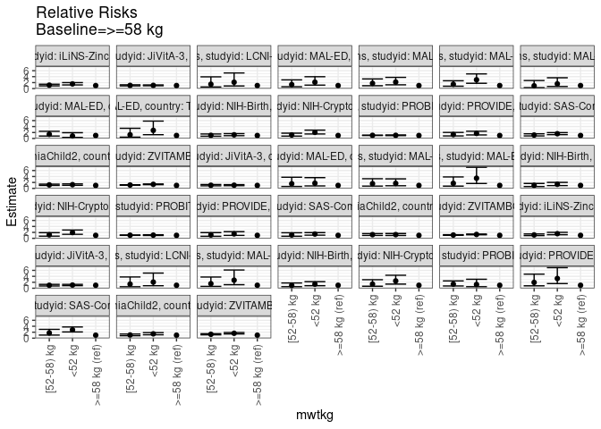

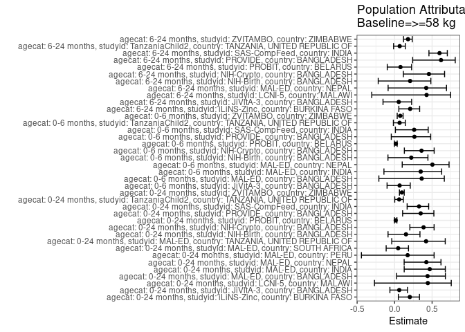

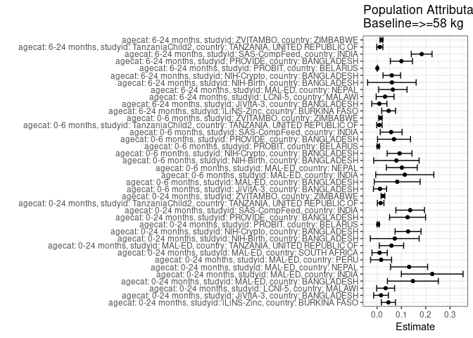

## Results Table

### Parameter: TSM

| agecat | studyid | country | intervention_level | baseline_level | estimate | ci_lower | ci_upper |
| --- | --- | --- | --- | --- | --- | --- | --- |
| 0-24 months | iLiNS-Zinc | BURKINA FASO | >=58 kg | NA | 0.1815657 | 0.1342653 | 0.2288660 |
| 0-24 months | iLiNS-Zinc | BURKINA FASO | <52 kg | NA | 0.2820754 | 0.2547114 | 0.3094393 |
| 0-24 months | iLiNS-Zinc | BURKINA FASO | [52-58) kg | NA | 0.2076954 | 0.1756125 | 0.2397782 |
| 0-24 months | JiVitA-3 | BANGLADESH | >=58 kg | NA | 0.2420365 | 0.2117633 | 0.2723096 |
| 0-24 months | JiVitA-3 | BANGLADESH | <52 kg | NA | 0.2585657 | 0.2519664 | 0.2651650 |
| 0-24 months | JiVitA-3 | BANGLADESH | [52-58) kg | NA | 0.2566828 | 0.2334168 | 0.2799487 |
| 0-24 months | LCNI-5 | MALAWI | >=58 kg | NA | 0.0438596 | 0.0062458 | 0.0814735 |
| 0-24 months | LCNI-5 | MALAWI | <52 kg | NA | 0.0932540 | 0.0678519 | 0.1186560 |
| 0-24 months | LCNI-5 | MALAWI | [52-58) kg | NA | 0.0636364 | 0.0313610 | 0.0959117 |
| 0-24 months | MAL-ED | BANGLADESH | >=58 kg | NA | 0.1875000 | 0.0768640 | 0.2981360 |
| 0-24 months | MAL-ED | BANGLADESH | <52 kg | NA | 0.4012346 | 0.3256079 | 0.4768612 |
| 0-24 months | MAL-ED | BANGLADESH | [52-58) kg | NA | 0.2500000 | 0.1218027 | 0.3781973 |
| 0-24 months | MAL-ED | INDIA | >=58 kg | NA | 0.2568003 | 0.1211764 | 0.3924242 |
| 0-24 months | MAL-ED | INDIA | <52 kg | NA | 0.5581390 | 0.4780271 | 0.6382508 |
| 0-24 months | MAL-ED | INDIA | [52-58) kg | NA | 0.4485809 | 0.3052508 | 0.5919109 |
| 0-24 months | MAL-ED | NEPAL | >=58 kg | NA | 0.1793889 | 0.0951023 | 0.2636754 |
| 0-24 months | MAL-ED | NEPAL | <52 kg | NA | 0.5286268 | 0.4174862 | 0.6397674 |
| 0-24 months | MAL-ED | NEPAL | [52-58) kg | NA | 0.2569512 | 0.1606213 | 0.3532812 |
| 0-24 months | MAL-ED | PERU | >=58 kg | NA | 0.0769231 | 0.0256217 | 0.1282244 |
| 0-24 months | MAL-ED | PERU | <52 kg | NA | 0.1217391 | 0.0618737 | 0.1816046 |
| 0-24 months | MAL-ED | PERU | [52-58) kg | NA | 0.0704225 | 0.0108059 | 0.1300392 |
| 0-24 months | MAL-ED | SOUTH AFRICA | >=58 kg | NA | 0.2010309 | 0.1445308 | 0.2575311 |
| 0-24 months | MAL-ED | SOUTH AFRICA | <52 kg | NA | 0.1666667 | 0.0330604 | 0.3002730 |
| 0-24 months | MAL-ED | SOUTH AFRICA | [52-58) kg | NA | 0.2826087 | 0.1522483 | 0.4129691 |
| 0-24 months | MAL-ED | TANZANIA, UNITED REPUBLIC OF | >=58 kg | NA | 0.0816327 | 0.0273170 | 0.1359483 |
| 0-24 months | MAL-ED | TANZANIA, UNITED REPUBLIC OF | <52 kg | NA | 0.2222222 | 0.1401678 | 0.3042766 |
| 0-24 months | MAL-ED | TANZANIA, UNITED REPUBLIC OF | [52-58) kg | NA | 0.1016949 | 0.0244209 | 0.1789689 |
| 0-24 months | NIH-Birth | BANGLADESH | >=58 kg | NA | 0.4052063 | 0.2978452 | 0.5125674 |
| 0-24 months | NIH-Birth | BANGLADESH | <52 kg | NA | 0.4994607 | 0.4531201 | 0.5458014 |
| 0-24 months | NIH-Birth | BANGLADESH | [52-58) kg | NA | 0.4295999 | 0.3297918 | 0.5294079 |

[output cut: 84 more lines]

### Parameter: E(Y)

| agecat | studyid | country | intervention_level | baseline_level | estimate | ci_lower | ci_upper |
| --- | --- | --- | --- | --- | --- | --- | --- |
| 0-24 months | iLiNS-Zinc | BURKINA FASO | NA | NA | 0.2278520 | 0.2008644 | 0.2548397 |
| 0-24 months | JiVitA-3 | BANGLADESH | NA | NA | 0.2580130 | 0.2515531 | 0.2644729 |
| 0-24 months | LCNI-5 | MALAWI | NA | NA | 0.0787589 | 0.0605107 | 0.0970072 |
| 0-24 months | MAL-ED | BANGLADESH | NA | NA | 0.3346457 | 0.2765014 | 0.3927899 |
| 0-24 months | MAL-ED | INDIA | NA | NA | 0.4834711 | 0.4203794 | 0.5465628 |
| 0-24 months | MAL-ED | NEPAL | NA | NA | 0.3109244 | 0.2519946 | 0.3698541 |
| 0-24 months | MAL-ED | PERU | NA | NA | 0.0931034 | 0.0596022 | 0.1266047 |
| 0-24 months | MAL-ED | SOUTH AFRICA | NA | NA | 0.2111111 | 0.1623431 | 0.2598792 |
| 0-24 months | MAL-ED | TANZANIA, UNITED REPUBLIC OF | NA | NA | 0.1406250 | 0.0979572 | 0.1832928 |
| 0-24 months | NIH-Birth | BANGLADESH | NA | NA | 0.4775641 | 0.4383415 | 0.5167867 |
| 0-24 months | NIH-Crypto | BANGLADESH | NA | NA | 0.3298013 | 0.2962438 | 0.3633589 |
| 0-24 months | PROBIT | BELARUS | NA | NA | 0.2805693 | 0.2183906 | 0.3427479 |
| 0-24 months | PROVIDE | BANGLADESH | NA | NA | 0.3602392 | 0.3238339 | 0.3966444 |
| 0-24 months | SAS-CompFeed | INDIA | NA | NA | 0.4172230 | 0.3585449 | 0.4759011 |
| 0-24 months | TanzaniaChild2 | TANZANIA, UNITED REPUBLIC OF | NA | NA | 0.2372449 | 0.2200495 | 0.2544403 |
| 0-24 months | ZVITAMBO | ZIMBABWE | NA | NA | 0.2457915 | 0.2378059 | 0.2537772 |
| 0-6 months | JiVitA-3 | BANGLADESH | NA | NA | 0.1761965 | 0.1705789 | 0.1818141 |
| 0-6 months | MAL-ED | BANGLADESH | NA | NA | 0.2283465 | 0.1766220 | 0.2800709 |
| 0-6 months | MAL-ED | INDIA | NA | NA | 0.3264463 | 0.2672449 | 0.3856476 |
| 0-6 months | MAL-ED | NEPAL | NA | NA | 0.2016807 | 0.1505956 | 0.2527658 |
| 0-6 months | NIH-Birth | BANGLADESH | NA | NA | 0.3569132 | 0.3192325 | 0.3945938 |
| 0-6 months | NIH-Crypto | BANGLADESH | NA | NA | 0.2569536 | 0.2257649 | 0.2881424 |
| 0-6 months | PROBIT | BELARUS | NA | NA | 0.2747604 | 0.2123223 | 0.3371985 |
| 0-6 months | PROVIDE | BANGLADESH | NA | NA | 0.2630792 | 0.2296894 | 0.2964690 |
| 0-6 months | SAS-CompFeed | INDIA | NA | NA | 0.2206573 | 0.1756202 | 0.2656944 |
| 0-6 months | TanzaniaChild2 | TANZANIA, UNITED REPUBLIC OF | NA | NA | 0.1403061 | 0.1262673 | 0.1543450 |
| 0-6 months | ZVITAMBO | ZIMBABWE | NA | NA | 0.1804281 | 0.1732799 | 0.1875764 |
| 6-24 months | iLiNS-Zinc | BURKINA FASO | NA | NA | 0.2278520 | 0.2008644 | 0.2548397 |
| 6-24 months | JiVitA-3 | BANGLADESH | NA | NA | 0.1638709 | 0.1577615 | 0.1699803 |
| 6-24 months | LCNI-5 | MALAWI | NA | NA | 0.0764563 | 0.0583018 | 0.0946108 |
| 6-24 months | MAL-ED | NEPAL | NA | NA | 0.1531915 | 0.1070438 | 0.1993392 |
| 6-24 months | NIH-Birth | BANGLADESH | NA | NA | 0.2933579 | 0.2549918 | 0.3317241 |
| 6-24 months | NIH-Crypto | BANGLADESH | NA | NA | 0.1315068 | 0.1069744 | 0.1560393 |
| 6-24 months | PROBIT | BELARUS | NA | NA | 0.0090817 | 0.0046144 | 0.0135489 |
| 6-24 months | PROVIDE | BANGLADESH | NA | NA | 0.1612378 | 0.1321259 | 0.1903497 |
| 6-24 months | SAS-CompFeed | INDIA | NA | NA | 0.3060781 | 0.2622443 | 0.3499120 |
| 6-24 months | TanzaniaChild2 | TANZANIA, UNITED REPUBLIC OF | NA | NA | 0.1612740 | 0.1450620 | 0.1774860 |
| 6-24 months | ZVITAMBO | ZIMBABWE | NA | NA | 0.0995484 | 0.0936035 | 0.1054934 |

### Parameter: RR

| agecat | studyid | country | intervention_level | baseline_level | estimate | ci_lower | ci_upper |
| --- | --- | --- | --- | --- | --- | --- | --- |
| 0-24 months | iLiNS-Zinc | BURKINA FASO | >=58 kg | >=58 kg | 1.0000000 | 1.0000000 | 1.000000 |
| 0-24 months | iLiNS-Zinc | BURKINA FASO | <52 kg | >=58 kg | 1.5535722 | 1.2124877 | 1.990607 |
| 0-24 months | iLiNS-Zinc | BURKINA FASO | [52-58) kg | >=58 kg | 1.1439133 | 0.9021519 | 1.450463 |
| 0-24 months | JiVitA-3 | BANGLADESH | >=58 kg | >=58 kg | 1.0000000 | 1.0000000 | 1.000000 |
| 0-24 months | JiVitA-3 | BANGLADESH | <52 kg | >=58 kg | 1.0682923 | 0.9402549 | 1.213765 |
| 0-24 months | JiVitA-3 | BANGLADESH | [52-58) kg | >=58 kg | 1.0605128 | 0.9039918 | 1.244134 |
| 0-24 months | LCNI-5 | MALAWI | >=58 kg | >=58 kg | 1.0000000 | 1.0000000 | 1.000000 |
| 0-24 months | LCNI-5 | MALAWI | <52 kg | >=58 kg | 2.1261905 | 0.8646020 | 5.228632 |
| 0-24 months | LCNI-5 | MALAWI | [52-58) kg | >=58 kg | 1.4509091 | 0.5357128 | 3.929600 |
| 0-24 months | MAL-ED | BANGLADESH | >=58 kg | >=58 kg | 1.0000000 | 1.0000000 | 1.000000 |
| 0-24 months | MAL-ED | BANGLADESH | <52 kg | >=58 kg | 2.1399177 | 1.1518112 | 3.975693 |
| 0-24 months | MAL-ED | BANGLADESH | [52-58) kg | >=58 kg | 1.3333333 | 0.6101437 | 2.913704 |
| 0-24 months | MAL-ED | INDIA | >=58 kg | >=58 kg | 1.0000000 | 1.0000000 | 1.000000 |
| 0-24 months | MAL-ED | INDIA | <52 kg | >=58 kg | 2.1734360 | 1.2573288 | 3.757032 |
| 0-24 months | MAL-ED | INDIA | [52-58) kg | >=58 kg | 1.7468083 | 0.9429988 | 3.235783 |
| 0-24 months | MAL-ED | NEPAL | >=58 kg | >=58 kg | 1.0000000 | 1.0000000 | 1.000000 |
| 0-24 months | MAL-ED | NEPAL | <52 kg | >=58 kg | 2.9468205 | 1.7649384 | 4.920144 |
| 0-24 months | MAL-ED | NEPAL | [52-58) kg | >=58 kg | 1.4323700 | 0.7851663 | 2.613056 |
| 0-24 months | MAL-ED | PERU | >=58 kg | >=58 kg | 1.0000000 | 1.0000000 | 1.000000 |
| 0-24 months | MAL-ED | PERU | <52 kg | >=58 kg | 1.5826087 | 0.6910535 | 3.624394 |
| 0-24 months | MAL-ED | PERU | [52-58) kg | >=58 kg | 0.9154930 | 0.3116133 | 2.689640 |
| 0-24 months | MAL-ED | SOUTH AFRICA | >=58 kg | >=58 kg | 1.0000000 | 1.0000000 | 1.000000 |
| 0-24 months | MAL-ED | SOUTH AFRICA | <52 kg | >=58 kg | 0.8290598 | 0.3545375 | 1.938695 |
| 0-24 months | MAL-ED | SOUTH AFRICA | [52-58) kg | >=58 kg | 1.4057971 | 0.8191006 | 2.412726 |
| 0-24 months | MAL-ED | TANZANIA, UNITED REPUBLIC OF | >=58 kg | >=58 kg | 1.0000000 | 1.0000000 | 1.000000 |
| 0-24 months | MAL-ED | TANZANIA, UNITED REPUBLIC OF | <52 kg | >=58 kg | 2.7222222 | 1.2718747 | 5.826434 |
| 0-24 months | MAL-ED | TANZANIA, UNITED REPUBLIC OF | [52-58) kg | >=58 kg | 1.2457627 | 0.4537299 | 3.420371 |
| 0-24 months | NIH-Birth | BANGLADESH | >=58 kg | >=58 kg | 1.0000000 | 1.0000000 | 1.000000 |
| 0-24 months | NIH-Birth | BANGLADESH | <52 kg | >=58 kg | 1.2326085 | 0.9306160 | 1.632600 |
| 0-24 months | NIH-Birth | BANGLADESH | [52-58) kg | >=58 kg | 1.0602003 | 0.7456070 | 1.507530 |

[output cut: 84 more lines]

### Parameter: PAR

| agecat | studyid | country | intervention_level | baseline_level | estimate | ci_lower | ci_upper |
| --- | --- | --- | --- | --- | --- | --- | --- |
| 0-24 months | iLiNS-Zinc | BURKINA FASO | >=58 kg | NA | 0.0462864 | 0.0170100 | 0.0755627 |
| 0-24 months | JiVitA-3 | BANGLADESH | >=58 kg | NA | 0.0159765 | -0.0142714 | 0.0462245 |
| 0-24 months | LCNI-5 | MALAWI | >=58 kg | NA | 0.0348993 | -0.0020178 | 0.0718164 |
| 0-24 months | MAL-ED | BANGLADESH | >=58 kg | NA | 0.1471457 | 0.0422895 | 0.2520018 |
| 0-24 months | MAL-ED | INDIA | >=58 kg | NA | 0.2266708 | 0.0995747 | 0.3537669 |
| 0-24 months | MAL-ED | NEPAL | >=58 kg | NA | 0.1315355 | 0.0553000 | 0.2077710 |
| 0-24 months | MAL-ED | PERU | >=58 kg | NA | 0.0161804 | -0.0270227 | 0.0593834 |
| 0-24 months | MAL-ED | SOUTH AFRICA | >=58 kg | NA | 0.0100802 | -0.0212756 | 0.0414360 |
| 0-24 months | MAL-ED | TANZANIA, UNITED REPUBLIC OF | >=58 kg | NA | 0.0589923 | 0.0088725 | 0.1091122 |
| 0-24 months | NIH-Birth | BANGLADESH | >=58 kg | NA | 0.0723578 | -0.0281986 | 0.1729142 |
| 0-24 months | NIH-Crypto | BANGLADESH | >=58 kg | NA | 0.1273238 | 0.0739615 | 0.1806861 |
| 0-24 months | PROBIT | BELARUS | >=58 kg | NA | 0.0040985 | -0.0002377 | 0.0084346 |
| 0-24 months | PROVIDE | BANGLADESH | >=58 kg | NA | 0.1253208 | 0.0511905 | 0.1994512 |
| 0-24 months | SAS-CompFeed | INDIA | >=58 kg | NA | 0.1359501 | 0.0770541 | 0.1948461 |
| 0-24 months | TanzaniaChild2 | TANZANIA, UNITED REPUBLIC OF | >=58 kg | NA | 0.0143926 | 0.0008010 | 0.0279841 |
| 0-24 months | ZVITAMBO | ZIMBABWE | >=58 kg | NA | 0.0238402 | 0.0159855 | 0.0316948 |
| 0-6 months | JiVitA-3 | BANGLADESH | >=58 kg | NA | 0.0117639 | -0.0153716 | 0.0388994 |
| 0-6 months | MAL-ED | BANGLADESH | >=58 kg | NA | 0.0825131 | -0.0118328 | 0.1768591 |
| 0-6 months | MAL-ED | INDIA | >=58 kg | NA | 0.1136898 | -0.0059004 | 0.2332801 |
| 0-6 months | MAL-ED | NEPAL | >=58 kg | NA | 0.1016807 | 0.0381826 | 0.1651787 |
| 0-6 months | NIH-Birth | BANGLADESH | >=58 kg | NA | 0.0793271 | -0.0140678 | 0.1727220 |
| 0-6 months | NIH-Crypto | BANGLADESH | >=58 kg | NA | 0.0922269 | 0.0411197 | 0.1433341 |
| 0-6 months | PROBIT | BELARUS | >=58 kg | NA | 0.0044013 | -0.0004615 | 0.0092642 |
| 0-6 months | PROVIDE | BANGLADESH | >=58 kg | NA | 0.0695164 | 0.0014971 | 0.1375356 |
| 0-6 months | SAS-CompFeed | INDIA | >=58 kg | NA | 0.0575972 | 0.0126409 | 0.1025534 |
| 0-6 months | TanzaniaChild2 | TANZANIA, UNITED REPUBLIC OF | >=58 kg | NA | 0.0093176 | -0.0018434 | 0.0204787 |
| 0-6 months | ZVITAMBO | ZIMBABWE | >=58 kg | NA | 0.0134554 | 0.0063697 | 0.0205410 |
| 6-24 months | iLiNS-Zinc | BURKINA FASO | >=58 kg | NA | 0.0472378 | 0.0184150 | 0.0760606 |
| 6-24 months | JiVitA-3 | BANGLADESH | >=58 kg | NA | 0.0090476 | -0.0220393 | 0.0401345 |
| 6-24 months | LCNI-5 | MALAWI | >=58 kg | NA | 0.0325967 | -0.0041856 | 0.0693789 |
| 6-24 months | MAL-ED | NEPAL | >=58 kg | NA | 0.0645839 | 0.0060879 | 0.1230799 |
| 6-24 months | NIH-Birth | BANGLADESH | >=58 kg | NA | 0.0606259 | -0.0391993 | 0.1604510 |
| 6-24 months | NIH-Crypto | BANGLADESH | >=58 kg | NA | 0.0601508 | 0.0240650 | 0.0962367 |
| 6-24 months | PROBIT | BELARUS | >=58 kg | NA | 0.0007124 | -0.0005764 | 0.0020011 |
| 6-24 months | PROVIDE | BANGLADESH | >=58 kg | NA | 0.0998343 | 0.0543326 | 0.1453359 |
| 6-24 months | SAS-CompFeed | INDIA | >=58 kg | NA | 0.1833046 | 0.1406184 | 0.2259908 |
| 6-24 months | TanzaniaChild2 | TANZANIA, UNITED REPUBLIC OF | >=58 kg | NA | 0.0109174 | -0.0017031 | 0.0235379 |
| 6-24 months | ZVITAMBO | ZIMBABWE | >=58 kg | NA | 0.0178135 | 0.0119510 | 0.0236761 |

### Parameter: PAF

| agecat | studyid | country | intervention_level | baseline_level | estimate | ci_lower | ci_upper |
| --- | --- | --- | --- | --- | --- | --- | --- |
| 0-24 months | iLiNS-Zinc | BURKINA FASO | >=58 kg | NA | 0.2031422 | 0.0499251 | 0.3316503 |
| 0-24 months | JiVitA-3 | BANGLADESH | >=58 kg | NA | 0.0619215 | -0.0627838 | 0.1719941 |
| 0-24 months | LCNI-5 | MALAWI | >=58 kg | NA | 0.4431154 | -0.2685075 | 0.7555233 |
| 0-24 months | MAL-ED | BANGLADESH | >=58 kg | NA | 0.4397059 | 0.0269915 | 0.6773620 |
| 0-24 months | MAL-ED | INDIA | >=58 kg | NA | 0.4688405 | 0.1279128 | 0.6764882 |
| 0-24 months | MAL-ED | NEPAL | >=58 kg | NA | 0.4230466 | 0.1273031 | 0.6185672 |
| 0-24 months | MAL-ED | PERU | >=58 kg | NA | 0.1737892 | -0.4426530 | 0.5268271 |
| 0-24 months | MAL-ED | SOUTH AFRICA | >=58 kg | NA | 0.0477482 | -0.1127541 | 0.1850999 |
| 0-24 months | MAL-ED | TANZANIA, UNITED REPUBLIC OF | >=58 kg | NA | 0.4195011 | -0.0382341 | 0.6754307 |
| 0-24 months | NIH-Birth | BANGLADESH | >=58 kg | NA | 0.1515143 | -0.0876967 | 0.3381170 |
| 0-24 months | NIH-Crypto | BANGLADESH | >=58 kg | NA | 0.3860621 | 0.2034891 | 0.5267865 |
| 0-24 months | PROBIT | BELARUS | >=58 kg | NA | 0.0146077 | -0.0016728 | 0.0306237 |
| 0-24 months | PROVIDE | BANGLADESH | >=58 kg | NA | 0.3478823 | 0.1068873 | 0.5238480 |
| 0-24 months | SAS-CompFeed | INDIA | >=58 kg | NA | 0.3258453 | 0.1670730 | 0.4543524 |
| 0-24 months | TanzaniaChild2 | TANZANIA, UNITED REPUBLIC OF | >=58 kg | NA | 0.0606654 | 0.0017033 | 0.1161450 |
| 0-24 months | ZVITAMBO | ZIMBABWE | >=58 kg | NA | 0.0969934 | 0.0645423 | 0.1283187 |
| 0-6 months | JiVitA-3 | BANGLADESH | >=58 kg | NA | 0.0667657 | -0.1006062 | 0.2086850 |
| 0-6 months | MAL-ED | BANGLADESH | >=58 kg | NA | 0.3613506 | -0.2099737 | 0.6629075 |
| 0-6 months | MAL-ED | INDIA | >=58 kg | NA | 0.3482650 | -0.1423845 | 0.6281826 |
| 0-6 months | MAL-ED | NEPAL | >=58 kg | NA | 0.5041667 | 0.1014472 | 0.7263926 |
| 0-6 months | NIH-Birth | BANGLADESH | >=58 kg | NA | 0.2222589 | -0.0886897 | 0.4443952 |
| 0-6 months | NIH-Crypto | BANGLADESH | >=58 kg | NA | 0.3589243 | 0.1299272 | 0.5276509 |
| 0-6 months | PROBIT | BELARUS | >=58 kg | NA | 0.0160188 | -0.0027343 | 0.0344212 |
| 0-6 months | PROVIDE | BANGLADESH | >=58 kg | NA | 0.2642412 | -0.0443098 | 0.4816279 |
| 0-6 months | SAS-CompFeed | INDIA | >=58 kg | NA | 0.2610255 | 0.0104655 | 0.4481412 |
| 0-6 months | TanzaniaChild2 | TANZANIA, UNITED REPUBLIC OF | >=58 kg | NA | 0.0664093 | -0.0163628 | 0.1424404 |
| 0-6 months | ZVITAMBO | ZIMBABWE | >=58 kg | NA | 0.0745746 | 0.0345411 | 0.1129482 |
| 6-24 months | iLiNS-Zinc | BURKINA FASO | >=58 kg | NA | 0.2073179 | 0.0564665 | 0.3340513 |
| 6-24 months | JiVitA-3 | BANGLADESH | >=58 kg | NA | 0.0552119 | -0.1547238 | 0.2269800 |
| 6-24 months | LCNI-5 | MALAWI | >=58 kg | NA | 0.4263436 | -0.3046507 | 0.7477627 |
| 6-24 months | MAL-ED | NEPAL | >=58 kg | NA | 0.4215893 | -0.0867215 | 0.6921392 |
| 6-24 months | NIH-Birth | BANGLADESH | >=58 kg | NA | 0.2066617 | -0.2186928 | 0.4835568 |
| 6-24 months | NIH-Crypto | BANGLADESH | >=58 kg | NA | 0.4573967 | 0.1166376 | 0.6667072 |
| 6-24 months | PROBIT | BELARUS | >=58 kg | NA | 0.0784387 | -0.0981712 | 0.2266459 |
| 6-24 months | PROVIDE | BANGLADESH | >=58 kg | NA | 0.6191742 | 0.2410369 | 0.8089126 |
| 6-24 months | SAS-CompFeed | INDIA | >=58 kg | NA | 0.5988817 | 0.4579734 | 0.7031586 |
| 6-24 months | TanzaniaChild2 | TANZANIA, UNITED REPUBLIC OF | >=58 kg | NA | 0.0676946 | -0.0137157 | 0.1425669 |
| 6-24 months | ZVITAMBO | ZIMBABWE | >=58 kg | NA | 0.1789434 | 0.1187720 | 0.2350062 |